# 파이썬 기본_집합형 자료형

## 2. 튜블

튜플(tuple)은 몇 가지 점을 제외하곤 리스트와 거의 비슷하며 리스트와 다른 점은 다음과 같다.

- 리스트는 [ ]으로 둘러싸지만 튜플은 ( )으로 둘러싼다.
- 순서가 있는 수정 불가능한 객체
- 리스트는 그 값의 생성, 인덱싱과 슬라이싱은 가능하지만 튜플은 그 값을 바꿀 수 없다.

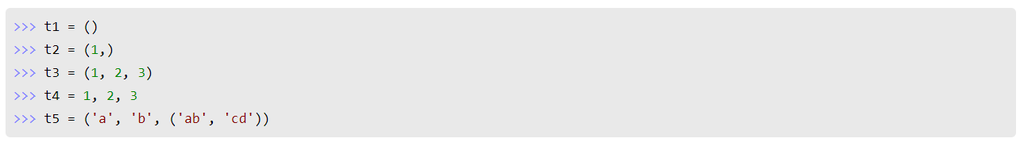

```python
t1=()
print(type(t1))
t2=1,
print(type(t2))
t4=(1,2,3)
print(t3)
t1,t2,t3=(1,2,3)
print(t1)
print(t2)
print(t3)
print(t4[0])
```

```
<class 'tuple'>
<class 'tuple'>
3
1
2
3
1
```

## 3. 딕셔너리

- 딕셔너리는 키와 값 { }로 되어 있다.
  - 예: {key1:valeu1, key2:value2...}
- 키(key)는 변하지 않는 값, 값(Value)에는 변하는 값을 매핑한다.
- 카(key)값은 중복되지 않고, 만약 중복되면 마지막 값만 기억하고 나머지는 무시한다.
- 딕셔너리 타입은 순서가 없는 집합입니다. (즉, 인덱싱과 슬라이싱을 사용못함, key값으로 접근함)

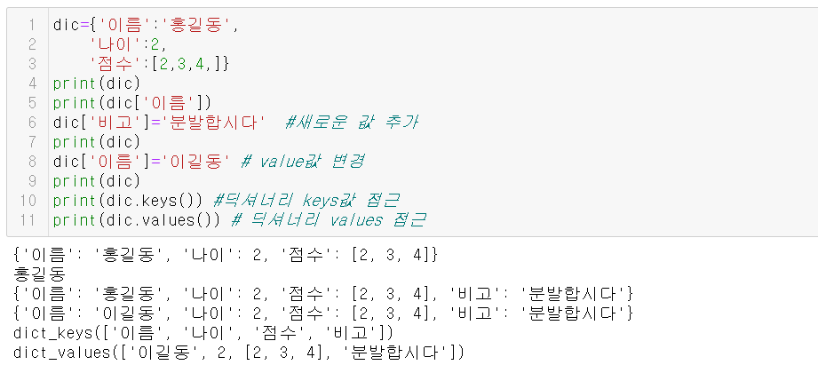

## 4. 집합

- set은 수학에서 이야기하는 집합과 비슷합니다.
- 순서가 없고, 집합안에서는 unique한 값을 가집니다.(인덱싱, 슬라이싱 안됨)
- 중괄호를 사용하는 것은 dictionary와 비슷하지만, key가 없습니다. 값만 존재합니다.

> 주로 중복된 값을 제거할 때 사용함

```python
s={1,1,2,3,3}
type(s)
print(s)

a=['홍길동','이두리','이하나','홍길동','이하나']
a=list(set(a))
print(a)
```

```
{1, 2, 3}
['이하나', '이두리', '홍길동']
```

## range()

```python
# range(숫자): 0에서 숫자-1까지 연속된 숫자 생성
range(10)
```

```
range(0, 10)
```

```python
#range()를 사용하여 리스트 만들기
list(range(10))
```

```
[0, 1, 2, 3, 4, 5, 6, 7, 8, 9]
```

```python
#range(시작,끝,증가폭)
r1=range(1,10)
print(list(r1))
r2=range(1,10,2)
print(list(r2))
```

```
[1, 2, 3, 4, 5, 6, 7, 8, 9]
[1, 3, 5, 7, 9]
```

연습문제  
다음 리스트 변수에 있는 각 데이터를 한 라인에 하나씩 출력하세요  
dt = ["python", "coding", "IoT", "Bigdata", "web", "크롤링"]  
예:  
python  
coding  
IoT

```python
dt = ["python", "coding", "IoT", "Bigdata", "web", "크롤링"]
print(dt[0])
print(dt[1])
print(dt[2])
print(dt[3])
print(dt[4])
print(dt[5])
```

```
python
coding
IoT
Bigdata
web
크롤링
```

연습문제  
1. 리스트 변수에서 가장 큰 값을 출력하세요: sort()활용  
2. 리스트 변수에서 가장 작은 값을 출력하세요:  
dt= [2, 6, 4]  
[결과]  
최대값: 6  
최소값:2

```python
dt=[2,6,4]
dt.sort()
print('최대값: {}'.format(dt[-1]))
print('최소값: {}'.format(dt[0]))
```

```
최대값: 6
최소값: 2
```

연습문제  
다음 리스트 변수에 있는 각 데이터에 2를 곱한 값을 한 라인에 하나씩 출력하세요  
dt = [2, 4, 6]  
예: 4 8 12

```python
#print()만 활용
dt=[2,4,5]
print(dt[0]*2, end=' ')
print(dt[1]*2, end=' ')
print(dt[2]*2, end=' ')
```

```
4 8 10
```

```python
#for문 활용(1):
dt=[2,4,5]
for i in dt:
    print(i*2,end=' ')
```

```
4 8 10
```

```python
#for문 활용(2)
dt=[2,4,5]
ls=[]
for i in dt:
    ls.append(i*2)
ls
```

```
[4, 8, 10]
```

```python
# 사용자 지정함수 활용

def multiples(df):
    ls=[]
    for i in df:
        ls.append(i*2)
    return(ls)
```

```python
df=[2,4,5]
multiples(df)
```

```
[4, 8, 10]
```

```python
df=[
    [2,4,5],
    [4,5,6],
    [1,2,3],
    [3,4,5]
]
ls=[]
for i in df:
    ls.append(multiples(i))
print(ls)
```

```
[[4, 8, 10], [8, 10, 12], [2, 4, 6], [6, 8, 10]]
```